# R Notebook

### TP 1: Analisis exploratorio e Introduccion a Regresión lineal

```r
library(tidyverse)
library(pander)
```

```r
library(dplyr)
library(tidyr)
library(ggplot2)
library(lubridate)
library(GGally)
library(corrr)
library(knitr)
library(kableExtra)
options(knitr.table.format = "html")

library(ggplot2)
library(ggthemes)  # estilos de gráficos
library(ggrepel)   # etiquetas de texto más prolijas que las de ggplot
library(scales)    # tiene la función 'percent()'
library(modelr)
library(plotly)
options(na.action = na.warn)
```

1. Preparacion de los datos
   1. Leer el archivo y mostrar su estructura

```r
datos <- read.table("C:/Users/susan/Downloads/AUBADM_EEA/EEA2019/trabajos_practicos/TP-1/ar_properties.csv",
                              sep=",", dec=".", header = TRUE, fill = TRUE, quote = "\""
                 )
```

```r
glimpse(datos)
```

```
Observations: 388,891
Variables: 24
$ id              <fct> S0we3z3V2JpHUJreqQ2t/w==, kMxcmAS8NvrynGBVbMOEaQ==, Ce3ojF+ZTOkB8d+LI9dpx...
$ ad_type         <fct> Propiedad, Propiedad, Propiedad, Propiedad, Propiedad, Propiedad, Propied...
$ start_date      <fct> 2019-04-14, 2019-04-14, 2019-04-14, 2019-04-14, 2019-04-14, 2019-04-14, 2...
$ end_date        <fct> 2019-06-14, 2019-04-16, 9999-12-31, 9999-12-31, 2019-07-09, 2019-08-08, 2...
$ created_on      <fct> 2019-04-14, 2019-04-14, 2019-04-14, 2019-04-14, 2019-04-14, 2019-04-14, 2...
$ lat             <dbl> -34.94331, -34.63181, NA, -34.65471, -34.65495, -32.93547, -34.65183, -34...
$ lon             <dbl> -54.92966, -58.42060, NA, -58.79089, -58.78712, -60.68398, -58.65912, -54...
$ l1              <fct> Uruguay, Argentina, Argentina, Argentina, Argentina, Argentina, Argentina...
$ l2              <fct> Maldonado, Capital Federal, Bs.As. G.B.A. Zona Norte, Bs.As. G.B.A. Zona ...
$ l3              <fct> Punta del Este, Boedo, NA, Moreno, Moreno, Rosario, ItuzaingÃ³, JosÃ© Ign...
$ l4              <fct> NA, NA, NA, Moreno, Moreno, NA, ItuzaingÃ³, NA, NA, NA, NA, NA, NA, NA, N...
$ l5              <fct> NA, NA, NA, NA, NA, NA, NA, NA, NA, NA, NA, NA, NA, NA, NA, NA, NA, NA, N...
$ l6              <lgl> NA, NA, NA, NA, NA, NA, NA, NA, NA, NA, NA, NA, NA, NA, NA, NA, NA, NA, N...
$ rooms           <int> 2, NA, 2, 2, 2, 4, NA, 6, NA, NA, NA, NA, NA, NA, NA, NA, NA, NA, NA, NA,...
$ bedrooms        <int> NA, NA, NA, NA, NA, NA, NA, NA, NA, NA, NA, NA, NA, NA, NA, NA, NA, NA, N...
$ bathrooms       <int> 1, NA, 1, 2, 3, 1, 3, 3, NA, NA, NA, NA, NA, NA, NA, NA, NA, NA, 1, NA, 1...
$ surface_total   <int> 45, NA, 200, 460, 660, NA, 70, NA, 1300, 405, 352, 373, 360, 1325, 250, 8...
$ surface_covered <int> 40, NA, NA, 100, 148, 89, 122, NA, NA, NA, NA, NA, NA, 2, NA, NA, NA, NA,...
$ price           <int> 13000, 0, NA, NA, NA, NA, NA, NA, 0, NA, 0, NA, NA, NA, NA, NA, 0, 0, 0, ...
$ currency        <fct> UYU, NA, NA, NA, NA, NA, NA, NA, NA, NA, NA, NA, NA, NA, NA, NA, NA, NA, ...
$ price_period    <fct> Mensual, Mensual, NA, Mensual, Mensual, Mensual, Mensual, Mensual, Mensua...
$ title           <fct> Departamento - Roosevelt, PH - Boedo, Ituzaingo  1100 - $ 1 - Casa Alquil...
$ property_type   <fct> Departamento, PH, Casa, Casa, Casa, Casa, Casa, Casa, Lote, Lote, Lote, L...
$ operation_type  <fct> Alquiler, Venta, Alquiler, Venta, Venta, Venta, Venta, Alquiler, Venta, V...
```

2. Quedarse con aquellos registros que:
   1. Pertenecen a Argentina y Capital Federal
   2. Cuyo precio esta en dolares (USD)
   3. El tipo de propiedad sea: Departamento, PH o Casa
   4. El tipo de operacion sea Venta
3. Seleccionar las variables **id**, **l3**, **rooms**, **bedrooms**, **bathrooms**, **surface_total**, **surface_covered**, **price** y **property_type**

```r
datos_sel <- datos %>%
  filter(l1=="Argentina" & l2=="Capital Federal"  & currency=="USD" &
          (property_type=="Departamento" |property_type=="Casa" | property_type=="PH")  &
          operation_type=="Venta"  ) %>%
  select(id, l3, rooms, bedrooms, bathrooms, surface_total, surface_covered,price,property_type)

nrow(datos_sel)
```

```
[1] 61868
```

2. Analisis exploratorios (I)
   1. Obtener la cantidad de valores unicos y de valores faltantes (NAs) para cada una de estas variables

# Valores Unicos

Lo hice de dos formas: Primero, obtuve los valores de cada columna por separado:

```r
datos_sel %>%   group_by(l3) %>% summarise(n())
```

```
Factor `l3` contains implicit NA, consider using `forcats::fct_explicit_na`
```

| l3 | n() |
| --- | --- |
| Abasto | 293 |
| AgronomÃa | 108 |
| Almagro | 4261 |
| Balvanera | 1872 |
| Barracas | 568 |
| Barrio Norte | 2479 |
| Belgrano | 5294 |
| Boca | 223 |
| Boedo | 639 |
| Caballito | 4279 |

[output cut: 48 more lines]

```r
datos_sel %>%   group_by(rooms) %>% summarise(n())
```

| rooms | n() |
| --- | --- |
| 1 | 10001 |
| 2 | 15489 |
| 3 | 15998 |
| 4 | 10112 |
| 5 | 3111 |
| 6 | 1059 |
| 7 | 388 |
| 8 | 219 |
| 9 | 60 |
| 10 | 52 |

[output cut: 14 more lines]

```r
datos_sel %>%   group_by(bedrooms) %>% summarise(n())
```

| bedrooms | n() |
| --- | --- |
| 0 | 425 |
| 1 | 13378 |
| 2 | 11731 |
| 3 | 8036 |
| 4 | 2158 |
| 5 | 461 |
| 6 | 221 |
| 7 | 131 |
| 8 | 24 |
| 9 | 8 |

[output cut: 15 more lines]

```r
datos_sel %>%   group_by(bathrooms) %>% summarise(n())
```

| bathrooms | n() |
| --- | --- |
| 1 | 37991 |
| 2 | 14209 |
| 3 | 4315 |
| 4 | 1501 |
| 5 | 465 |
| 6 | 134 |
| 7 | 21 |
| 8 | 7 |
| 9 | 8 |
| 10 | 12 |

[output cut: 5 more lines]

```r
datos_sel %>%   group_by(surface_total) %>% summarise(n())
```

| surface_total | n() |
| --- | --- |
| 0 | 21 |
| 10 | 2 |
| 11 | 3 |
| 12 | 5 |
| 13 | 7 |
| 14 | 6 |
| 15 | 9 |
| 16 | 12 |
| 17 | 9 |
| 18 | 28 |

[output cut: 661 more lines]

```r
datos_sel %>%   group_by(surface_covered) %>% summarise(n())
```

| surface_covered | n() |
| --- | --- |
| 0 | 1 |
| 1 | 23 |
| 2 | 3 |
| 3 | 8 |
| 4 | 8 |
| 5 | 4 |
| 6 | 2 |
| 7 | 2 |
| 8 | 4 |
| 10 | 5 |

[output cut: 563 more lines]

```r
datos_sel %>%   group_by(price) %>% summarise(n())
```

| price | n() |
| --- | --- |
| 6000 | 3 |
| 7500 | 1 |
| 10000 | 1 |
| 11258 | 1 |
| 11803 | 1 |
| 12000 | 6 |
| 12345 | 1 |
| 12500 | 2 |
| 13000 | 2 |
| 14000 | 1 |

[output cut: 990 more lines]

```r
datos_sel %>%   group_by(property_type) %>% summarise(n())
```

| property_type | n() |
| --- | --- |
| Casa | 3696 |
| Departamento | 52390 |
| PH | 5782 |

Segundo, hice una función que obtenga los valores y cantidades para una columna luego la uso con map. Tuve un error que me sale por tipo de datos, si pongo juntas todas las columnas las de tipo numerico y las string. Entonces primero, aplico map sobre las columnas string, y luego sobre las numéricas.

```r
calcular_valores <- function(columna) {
  datos_col <- datos_sel[c(columna)]
  colnames(datos_col) <- c("valor")
  datos_col %>%   group_by(valor) %>% summarise(n())
}

campos <- c("property_type","l3")
bases_df <- tibble(campos) %>%
  mutate(base = purrr::map(campos, calcular_valores))
```

```
Factor `valor` contains implicit NA, consider using `forcats::fct_explicit_na`
```

```r
bases_df %>% unnest()
```

```
Unequal factor levels: coercing to characterbinding character and factor vector, coercing into character vectorbinding character and factor vector, coercing into character vector
```

| campos | valor | n() |
| --- | --- | --- |
| property_type | Casa | 3696 |
| property_type | Departamento | 52390 |
| property_type | PH | 5782 |
| l3 | Abasto | 293 |
| l3 | AgronomÃa | 108 |
| l3 | Almagro | 4261 |
| l3 | Balvanera | 1872 |
| l3 | Barracas | 568 |
| l3 | Barrio Norte | 2479 |
| l3 | Belgrano | 5294 |

[output cut: 51 more lines]

```r
campos <- c("rooms","bedrooms","bathrooms")
bases_df <- tibble(campos) %>%
  mutate(base = purrr::map(campos, calcular_valores))

bases_df %>% unnest()
```

| campos | valor | n() |
| --- | --- | --- |
| rooms | 1 | 10001 |
| rooms | 2 | 15489 |
| rooms | 3 | 15998 |
| rooms | 4 | 10112 |
| rooms | 5 | 3111 |
| rooms | 6 | 1059 |
| rooms | 7 | 388 |
| rooms | 8 | 219 |
| rooms | 9 | 60 |
| rooms | 10 | 52 |

[output cut: 54 more lines]

```r
NA
```

# Valores Faltantes

Similar a lo anterior, hice una función para calcular valores NA para una columna, y la apliqué en una lista con map

Efectivamente, se notan muchos valores NA para **bedrooms**

```r
calcular_valores_NA <- function(columna) {
  datos_col <- datos_sel[c(columna)]
  colnames(datos_col) <- c("valor")
  datos_col %>%   filter(is.na(valor)) %>% group_by(valor) %>% summarise(n())
}

campos <- c("rooms","bedrooms","bathrooms","property_type","l3","price","surface_total","surface_covered")
bases_df <- tibble(campos) %>%
  mutate(base = purrr::map(campos, calcular_valores_NA))
```

```
Factor `valor` contains implicit NA, consider using `forcats::fct_explicit_na`Factor `valor` contains implicit NA, consider using `forcats::fct_explicit_na`
```

```r
bases_df %>% unnest()
```

| campos | valor | n() |
| --- | --- | --- |
| rooms | NA | 5314 |
| bedrooms | NA | 25265 |
| bathrooms | NA | 3195 |
| property_type | NA | 0 |
| l3 | NA | 355 |
| surface_total | NA | 3671 |
| surface_covered | NA | 2975 |

```r
NA
```

2. Obtener la matriz de correlacion para las variables numericas. Pista: usen ‘complete.obs’ para poder omitir los valores faltantes.

Hice de dos maneras: primero con cor, y luego con correlate

Efectivamente, se nota alta correlación de **bedrooms** con **rooms**

```r
# de una forma
datos_sel_numeric <- datos_sel %>% select(-c(id,l3, property_type))
crm <- cor(datos_sel_numeric, use="complete.obs", method="pearson")

crm
```

```
                     rooms   bedrooms  bathrooms surface_total surface_covered      price
rooms           1.00000000 0.92138751 0.61334790    0.06828268      0.07468175 0.48748214
bedrooms        0.92138751 1.00000000 0.61577562    0.06746960      0.07206663 0.43220802
bathrooms       0.61334790 0.61577562 1.00000000    0.06234158      0.06776772 0.59903061
surface_total   0.06828268 0.06746960 0.06234158    1.00000000      0.69656223 0.05095146
surface_covered 0.07468175 0.07206663 0.06776772    0.69656223      1.00000000 0.06257752
price           0.48748214 0.43220802 0.59903061    0.05095146      0.06257752 1.00000000
```

```r
# de otra forma
datos_sel_numeric %>%
 correlate() %>%
  shave() %>%
  fashion()
```

```
Correlation method: 'pearson'
Missing treated using: 'pairwise.complete.obs'
```

| rowname | rooms | bedrooms | bathrooms | surface_total | surface_covered | price |
| --- | --- | --- | --- | --- | --- | --- |
| rooms |  |  |  |  |  |  |
| bedrooms | .92 |  |  |  |  |  |
| bathrooms | .63 | .63 |  |  |  |  |
| surface_total | .08 | .08 | .09 |  |  |  |
| surface_covered | .09 | .08 | .10 | .69 |  |  |
| price | .30 | .34 | .42 | .08 | .09 |  |

3. Preparacion de los datos (II)
   1. En el punto 2 deberian haber encontrado que la variable **bedrooms** presenta una alta proporción de valores faltantes y que presenta una fuerte correlacion con la variable **rooms**. Por lo tanto, vamos a eliminarla.
   2. Eliminar todos los registros que presentan valores faltantes

Deberian llegar a un dataset con 51210 observaciones y 8 variables

Bueno, no me coincidió la cantidad que queda, 51174

```r
datos_sel2 <- datos_sel  %>% select(-c(bedrooms))
datos_sel2 <- na.omit(datos_sel2)
nrow(datos_sel2)
```

```
[1] 51174
```

4. Analisis exploratorios (II) a) Obtener estadisticas descriptivas para la variable precio (cuartiles, promedio, minimo y maximo) y realizar un histograma de la variable

```r
mistads <- function(x){
                m <- mean(x)
                q <- quantile(x)
                n <- length(x)
                mi <- min(x)
                ma <- max(x)
                return(c(n=n, cuartiles=q, media=m, minimo=mi, maximo=ma))
}

resultados <- mistads(datos_sel2$price)

resultados  %>%
  kable(col.names = "Precio(USD)",digits=0) %>%
  kable_styling(position = "left", full_width = F)
```

|  | Precio(USD) |
| --- | --- |
| n | 51174 |
| cuartiles.0% | 6000 |
| cuartiles.25% | 119000 |
| cuartiles.50% | 170000 |
| cuartiles.75% | 270625 |
| cuartiles.100% | 6000000 |
| media | 251636 |
| minimo | 6000 |
| maximo | 6000000 |

```r
NA
NA
```

Histograma de variable Precio

Se nota una cola de valores grandes pero son pocos respecto del total

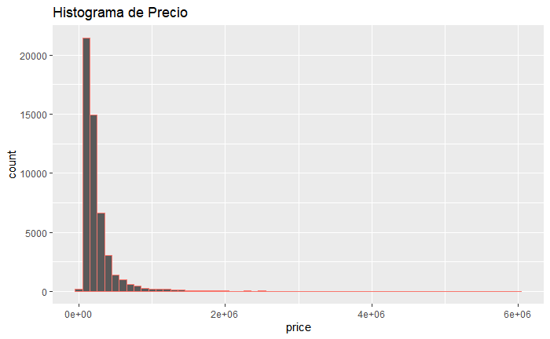

```r
ggplot(data = datos_sel2, aes(x = price, col="blue"))+
  geom_histogram(binwidth = 100000 )+
  labs(title = "Histograma de Precio")+
  theme(legend.position = 'none')
```

4b) Obtener estadisticas descriptivas para la variable precio (cuartiles, promedio, minimo y maximo) por cada tipo de propiedad.

```r
mistads2 <- function(x){
xx <-  datos_sel2[datos_sel2$property_type== x,c("price")]

                m <- round(mean(xx),2)
                q <- quantile(xx)
                n <- length(xx)
                mi <- min(xx)
                ma <- max(xx)
                return(c(n=n, cuartiles=q, media=m, minimo=mi, maximo=ma))
}


lista_tipos_prop <- unique( datos_sel2$property_type)
bases_df <- data.frame()
bases_df <- tibble(lista_tipos_prop) %>%
  mutate(resultado = purrr::map(lista_tipos_prop, mistads2))


bases_df  %>%
  kable(digits=0) %>%
  kable_styling(position = "left", full_width = F)
```

| lista_tipos_prop | resultado |
| --- | --- |
| Casa | c(n = 2025, `cuartiles.0%` = 20000, `cuartiles.25%` = 235000, `cuartiles.50%` = 335000, `cuartiles.75%` = 490000, `cuartiles.100%` = 5e+06, media = 434419.65, minimo = 20000, maximo = 5e+06) |
| Departamento | c(n = 44241, `cuartiles.0%` = 6000, `cuartiles.25%` = 115000, `cuartiles.50%` = 164000, `cuartiles.75%` = 260000, `cuartiles.100%` = 6e+06, media = 246913.32, minimo = 6000, maximo = 6e+06) |
| PH | c(n = 4908, `cuartiles.0%` = 32000, `cuartiles.25%` = 137000, `cuartiles.50%` = 190000, `cuartiles.75%` = 270500, `cuartiles.100%` = 1500000, media = 218791.54, minimo = 32000, maximo = 1500000) |

```r
NA
```

```
c) Realizar un grafico de boxplot de la variable precio por tipo de propiedad
```

Se nota en promedio las casas son mas caras que los demás y con más varianza. Los departamentos parecidos a los PH, aunque con más valores fuera del rango intercuartil.

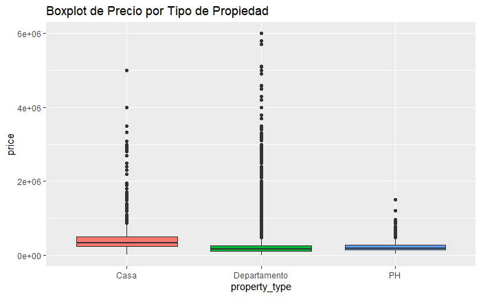

```r
ggplot(data = datos_sel2, aes(x= property_type,y = price, group= property_type, fill= property_type))+
  geom_boxplot()+
  labs(title = "Boxplot de Precio por Tipo de Propiedad")+
  theme(legend.position = 'none')+
  scale_y_continuous(limits = c(0, 6000000))
```

```
d) Realizar un correlagrama usando `GGAlly`

Se nota alta  correlación de :
surface_total con surface_covered,
price con bathroons y rooms,
rooms con bathrooms
```

```
data in column(s) 'id', 'l3', 'property_type' are not numeric and were ignored
```

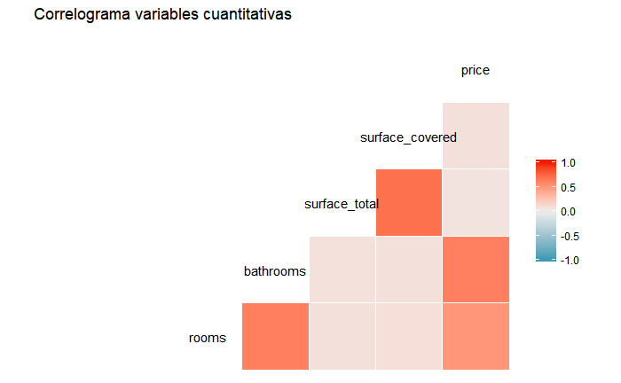

```r
ggcorr(datos_sel2, layout.exp = 2) + labs(title='Correlograma variables cuantitativas')
```

5. Outliers
   1. Eliminar los outliers de la variable **precio** con algún criterio que elijan: puede ser por valores de corte, eliminar el x% a izquierda y derecha,etc.

   Elijo calcular una variable nueva **precio_por_metro** para ayudarme a identificar propiedades que tengan valores incorrectos y que puedan ser outliers candidatos a eliminar. Es real que hay propiedades caras porque son muy grandes o por la categoría. Pero dentro de lo que conocemos en Capital,los valores lógicos llegan hasta un cierto valor. Lo mismo en el extremo inferior, no hay propiedades que valgan menos que cierto valor por metro cuadrado.

   Para observar, hago un histograma de los que tienen precio_por_metro superior a 7000 y otro para inferior a 400

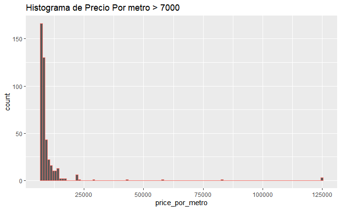

```r
# calculo variable precio_por_metro

datos_sel3 <- datos_sel2 %>% mutate( price_por_metro = price / surface_total)

# me fijo cuántos tienen valores extremos
ggplot(data = datos_sel3[datos_sel3$price_por_metro> 7000,], aes(x = price_por_metro, col="blue"))+
  geom_histogram(binwidth = 1000 )+
  labs(title = "Histograma de Precio Por metro > 7000")+
  theme(legend.position = 'none')
```

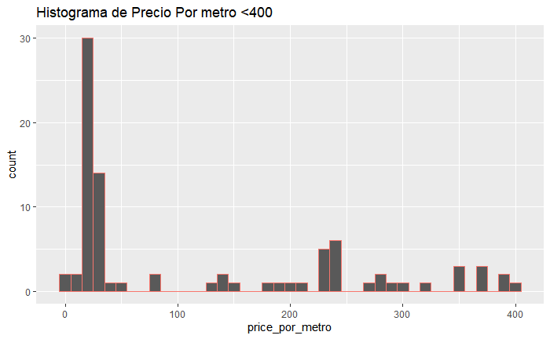

```r
ggplot(data = datos_sel3[datos_sel3$price_por_metro< 400,], aes(x = price_por_metro, col="blue"))+
  geom_histogram(binwidth = 10 )+
  labs(title = "Histograma de Precio Por metro <400")+
  theme(legend.position = 'none')
```

```r
NA
NA
```

Finalmente, marco como outliers los que tienen precio_por_metro < 400 o precio_por_metro > 7000 o precio <50000

```r
datos_sel3$outlier <- (datos_sel3$price_por_metro < 400 | datos_sel3$price < 50000 | datos_sel3$price_por_metro >  7000)

datos_sel3$color <- ifelse(datos_sel3$outlier, "red", "black")
```

6. Analisis exploratorios (III) Repetir los 4 análisis exploratorios realizados en el punto 4 y realizar unos breves comentarios sobre los cambios que encontraron
1. Obtener estadisticas descriptivas para la variable precio (cuartiles, promedio, minimo y maximo) y realizar un histograma de la variable

# me quedo con los que no marqué como outlier:

```r
datos_sel4 <- datos_sel3 %>% filter(!outlier)

mistads <- function(x){
                m <- mean(x)
                q <- quantile(x)
                n <- length(x)
                mi <- min(x)
                ma <- max(x)
                return(c(n=n, cuartiles=q, media=m, minimo=mi, maximo=ma))
}

resultados <- mistads(datos_sel4$price)

resultados  %>%
  kable(col.names = "Precio USD",digits=0) %>%
  kable_styling(position = "left", full_width = F)
```

|  | Precio USD |
| --- | --- |
| n | 50514 |
| cuartiles.0% | 50000 |
| cuartiles.25% | 119000 |
| cuartiles.50% | 169900 |
| cuartiles.75% | 270000 |
| cuartiles.100% | 5700000 |
| media | 240227 |
| minimo | 50000 |
| maximo | 5700000 |

```r
NA
```

Histograma de variable Precio

Observo que no varió mucho el histograma, no fue muy drástico la quita de outliers

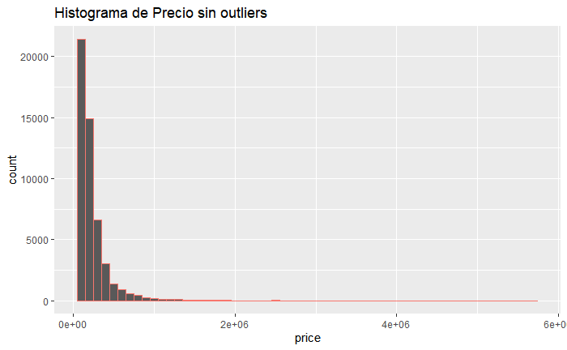

```r
ggplot(data = datos_sel4, aes(x = price, col="blue"))+
  geom_histogram(binwidth = 100000 )+
  labs(title = "Histograma de Precio sin outliers")+
  theme(legend.position = 'none')
```

6b) Obtener estadisticas descriptivas para la variable precio (cuartiles, promedio, minimo y maximo) por cada tipo de propiedad.

```r
mistads4 <- function(x){
xx <-  datos_sel4[datos_sel4$property_type== x,c("price")]

                m <- round(mean(xx),2)
                q <- quantile(xx)
                n <- length(xx)
                mi <- min(xx)
                ma <- max(xx)
                return(c(n=n, cuartiles=q, media=m, minimo=mi, maximo=ma))
}


lista_tipos_prop <- unique( datos_sel4$property_type)
bases_df <- data.frame()
bases_df <- tibble(lista_tipos_prop) %>%
  mutate(resultado = purrr::map(lista_tipos_prop, mistads4))


bases_df  %>%
  kable(digits=0) %>%
  kable_styling(position = "left", full_width = F)
```

| lista_tipos_prop | resultado |
| --- | --- |
| Casa | c(n = 2009, `cuartiles.0%` = 62000, `cuartiles.25%` = 235000, `cuartiles.50%` = 335000, `cuartiles.75%` = 490000, `cuartiles.100%` = 5e+06, media = 430352.42, minimo = 62000, maximo = 5e+06) |
| Departamento | c(n = 43620, `cuartiles.0%` = 50000, `cuartiles.25%` = 115000, `cuartiles.50%` = 162080, `cuartiles.75%` = 259000, `cuartiles.100%` = 5700000, media = 233825.01, minimo = 50000, maximo = 5700000) |
| PH | c(n = 4885, `cuartiles.0%` = 50000, `cuartiles.25%` = 138000, `cuartiles.50%` = 190000, `cuartiles.75%` = 274000, `cuartiles.100%` = 1500000, media = 219200.04, minimo = 50000, maximo = 1500000) |

```r
NA
```

6c) Realizar boxplot de precio por tipo de propiedad

Se observa parecido al bloxplot anterior

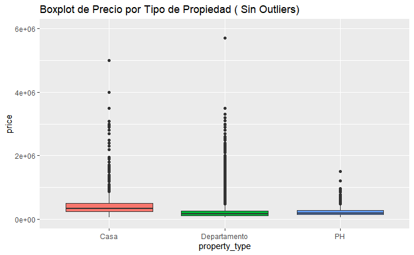

```r
ggplot(data = datos_sel4, aes(x= property_type,y = price, group= property_type, fill= property_type))+
  geom_boxplot()+
  labs(title = "Boxplot de Precio por Tipo de Propiedad ( Sin Outliers) ")+
  theme(legend.position = 'none')+
  scale_y_continuous(limits = c(0, 6000000))
```

6d) Realizar correlagrama usando Ggally

### AHORA SE NOTA LA CORRELACION DE PRECIO CON SUPERFICIE

```
data in column(s) 'id', 'l3', 'property_type', 'outlier', 'color' are not numeric and were ignored
```

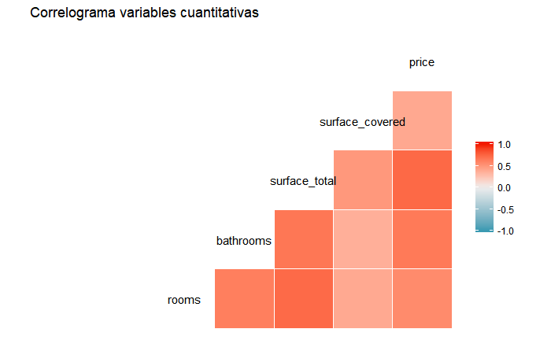

```r
datos_sel4_aux <- datos_sel4 %>% select(-price_por_metro)
ggcorr(datos_sel4_aux, layout.exp = 2) + labs(title='Correlograma variables cuantitativas')
```

7. realizar modelo de regresion lineal que explique el precio en funcion de las rooms y otro en funcion de la superficie total

Grafico precio en función de rooms, y precio en función de surface_total

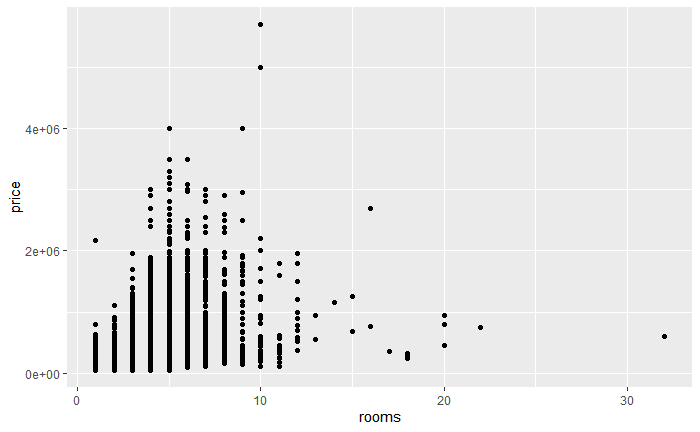

```r
ggplot(datos_sel4, aes(rooms, price) ) +
  geom_point()
```

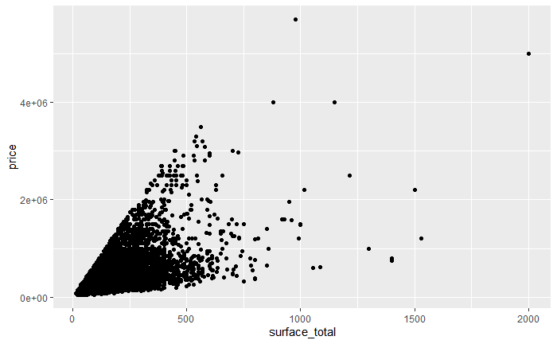

```r
ggplot(datos_sel4, aes(surface_total, price) ) +
  geom_point()
```

Hago los modelos y muestro los coeficientes

```r
rooms_mod <- lm(price ~ rooms, data = datos_sel4)
coef(rooms_mod)
```

```
(Intercept)       rooms
  -30666.18    96829.78
```

```r
surface_mod <- lm(price ~ surface_total, data = datos_sel4)
coef(surface_mod)
```

```
  (Intercept) surface_total
    37590.860      2235.742
```

$$Precio = -30666.18 + 96829.78 * rooms$$
$$Precio = 37590.860 + 2235.742 * surface\_total$$
el summary de cada uno

```r
summary(rooms_mod)
```

```
Call:
lm(formula = price ~ rooms, data = datos_sel4)

Residuals:
     Min       1Q   Median       3Q      Max
-2467887   -85823   -24993    38347  4762368

Coefficients:
            Estimate Std. Error t value Pr(>|t|)
(Intercept) -30666.2     1997.3  -15.35   <2e-16 ***
rooms        96829.8      639.3  151.46   <2e-16 ***
---
Signif. codes:  0 ‘***’ 0.001 ‘**’ 0.01 ‘*’ 0.05 ‘.’ 0.1 ‘ ’ 1

Residual standard error: 199800 on 50512 degrees of freedom
Multiple R-squared:  0.3123,    Adjusted R-squared:  0.3123
F-statistic: 2.294e+04 on 1 and 50512 DF,  p-value: < 2.2e-16
```

```r
summary(surface_mod)
```

```
Call:
lm(formula = price ~ surface_total, data = datos_sel4)

Residuals:
     Min       1Q   Median       3Q      Max
-2417629   -42456   -15192    21858  3475854

Coefficients:
               Estimate Std. Error t value Pr(>|t|)
(Intercept)   37590.860   1110.070   33.86   <2e-16 ***
surface_total  2235.742      9.233  242.14   <2e-16 ***
---
Signif. codes:  0 ‘***’ 0.001 ‘**’ 0.01 ‘*’ 0.05 ‘.’ 0.1 ‘ ’ 1

Residual standard error: 163900 on 50512 degrees of freedom
Multiple R-squared:  0.5372,    Adjusted R-squared:  0.5372
F-statistic: 5.863e+04 on 1 and 50512 DF,  p-value: < 2.2e-16
```

Grafico los puntos, y la recta del modelo

```r
##rooms
ggplot(datos_sel4, aes(rooms, price)) +
   geom_abline(intercept = -30666.2, slope = 96829.78, colour = "#3366FF") +
  geom_point(colour = "grey40")



ggplot(datos_sel4, aes(surface_total, price)) +
   geom_abline(intercept = 37590.86, slope =  2235.742, colour = "#3366FF") +
  geom_point(colour = "grey40")
```

[output not shown]

# Conclusiones

Dado que los p-valores son muy chicos, ambos modelos son estadisticamente signicativos El modelo que elegiría es el de precio en función de la superficie, porque tiene menor Residual standard error y mayor R-squared, lo que significa tiene menos residuos y explica mejor la variable precio.